# Econométrie de la finance

Chapitre 3: Les modèles non miléaires univariés

Mohamed Essaied Hamrita

Octobre 2021

# Introduction

- Dans ce chapitre nous introduisons quelques modèles non linéaires univariés et nous discutons leurs propriétes statistiques.
- Les modèles introduits sont: le modèle TAR (Threshold AR), le modèle Markov switching (MSM), smooth threshold autoregressive (STAR) models, et time-varying parameter models (TVM)

# Le modèle TAR

$\sigma^2_t$ est la **variance conditionnelle** du processus $X_t$, $\sigma^2_t=\mathbb{V}\left(X_t|\mathcal{I}_{t-1}\right)$.

Ce processus est proposé par (Engle 1982).

**Exemple:** Soit $X_t \sim ARCH(1)$. La figure suivante est une réalisation (simulation) du modèle $ARCH(1)$ définit par: $X_t=\varepsilon_t=\sigma_t Z_t$ et $\sigma^2_t=0.4+0.7\varepsilon^2_{t-1}$.

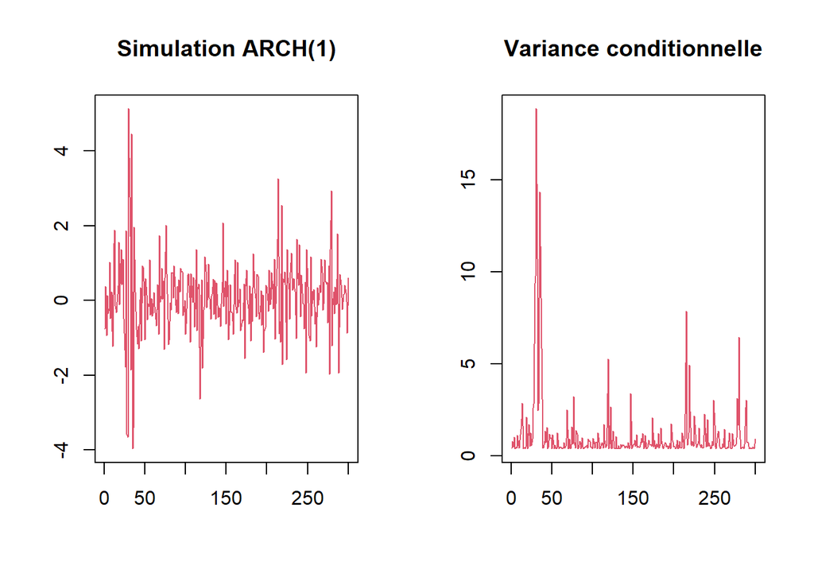

```r
library(fGarch); set.seed(12345)
arch1=garchSim(garchSpec(model=list(omega=0.4,alpha=0.7, beta=0)), n=300, extended = T)
par(mfrow=c(1,2))
plot(arch1$garch, type="l", col=2, main="Simulation ARCH(1)", xlab="", ylab="")
plot(arch1$sigma^2, type="l", col=2, main="Variance conditionnelle", xlab="", ylab="")
```

# Propriétés statistiques

Soit $X_t \sim ARCH(p)$. On a pour tout $t$ et $h \geq 1$,

- $\mathbb{E}\left(X_t|\mathcal{I}_{t-1} \right)=0$ et $\mathbb{E}\left(X_t \right)=0$.
- $\mathbb{V}\left(X_t|\mathcal{I}_{t-1} \right)= \sigma^2_t, \; \forall t$ et $\mathbb{V}\left(X_t \right)=\dfrac{a_0}{1-\displaystyle \sum_{i=1}^pa_i}$.
- $\mathbb{C}ov\left(X_t X_{t+h}|\mathcal{I}_{t-1} \right)=0$ pour $h \geq 1$ et $\mathbb{C}ov\left(X_t X_{t+h}\right)=0$.
- **Rappel**
- $\mathbb{E}(X)=\mathbb{E}\big(\mathbb{E}(X|Y)\big)$.
- Soit $A_1 \subseteq A_2$, $\mathbb{E}(X|A_1)=\mathbb{E}\big(\mathbb{E}(X|A_2)|A_1\big)$.

# La construction du modèle ARCH

- La construction du modèle ARCH passe par 4 étapes:
  1. Détermination de l’ordre $p$.
  2. Estimation du modèle $ARCH(p)$.
  3. Diagnostic du modèle estimé.
  4. Prévision.

**Détermination de l’ordre** $\mathbf{p}$**:**

- Similairement aux modèles ARMA, l’ordre $p$ peut être déterminé en examinant la fonction d’auto-corrélation partielle de $\varepsilon_t^2$.
- On peut aussi faire recours aux critères de sélection: AIC, BIC et AICc.
- $AIC=-2logL+2k$, (Akaike information criteria) $k=$ nombre de paramètres dans le modèle estimé.
- $BIC=-2logL+\log(T)k$. (Bayesian information criteria )
- Pour un échantillon de petite taille, on utilise le critère $AICc$ qui est défini par
  $$AICc=AIC+\dfrac{2k(k+1)}{T-k-1}$$

Reprenons notre exemple du chapitre précédent, les rendements du bitcoin.

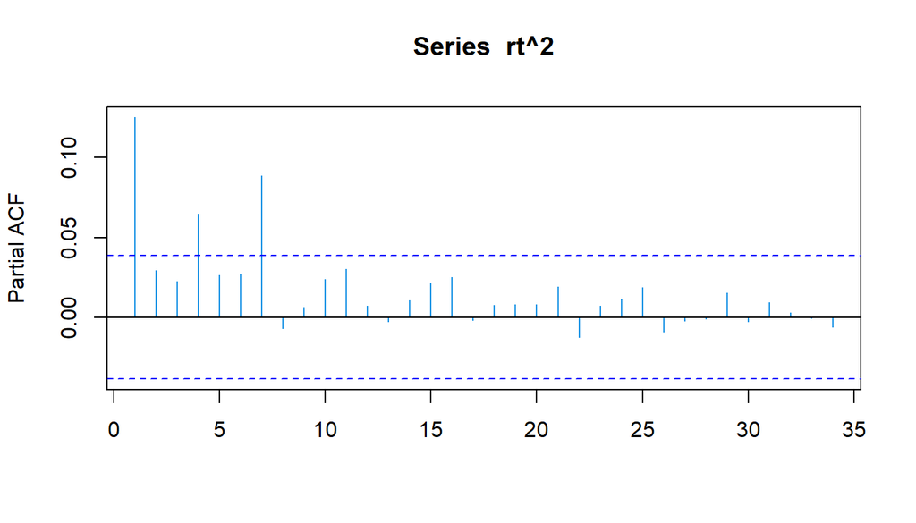

```r
library(quantmod); library(zoo)
btc=getSymbols("BTC-USD", src="yahoo", from="2014-09-17",to="2021-10-20",auto.assign = FALSE)
closedAdj=zoo(na.omit(btc[,6])); rt=diff(log(closedAdj))
pacf(rt^2,na.action = na.pass, col=4, xlab="")
```

D’après le graphique de la fonction d’auto-corrélation partielle de $r_t^2$, on remarque bien que le modèle ARCH d’ordre 1 est approprié aux rendements du BTC. On remarque aussi, que les pacf d’ordres 4 et 7 sont aussi significativement différents de zéro.

Déterminons les valeurs des critères d’information pour les modèles ARCH(1) et ARCH(4).

Sous R, il existe plusieurs packages permettant l’estimation des modèles GARCH tels que `tseries`, `fGarch`, `rugarch`.

Ici, nous décrivons l’utilisation des packages `fGarch` et `rugarch`. Pour l’estimation du modèle ARCH, nous devons spécifier le modèle à estimer en donnant les ordres des différents modèles (mean and variance equations).

La fonction à utiliser est `ugarchspec` (`rugarch`) et prend comme arguments principaux `variance.model`, `mean.model` et `distribution.model`. Les deux premiers arguments sont des listes et le toisième est une chaîne de caractère qui peut être `"norm"`, `"std"`, `"sstd` `"ged"` ou `sged`.

```r
library(rugarch)   # charger le package
spec1=ugarchspec(variance.model = list(garchOrder=c(1,0)),
                mean.model = list(armaOrder=c(0,0)))
spec4=ugarchspec(variance.model = list(garchOrder=c(4,0)),
                mean.model = list(armaOrder=c(0,0)))
fit1=ugarchfit(spec1,rt)  # Estimation
fit4=ugarchfit(spec4,rt)
t(infocriteria(fit1))  # critères d'information (normalisés)
```

```
    Akaike     Bayes   Shibata Hannan-Quinn
 0.5254326 0.5322282 0.5254299    0.5278955
```

```r
t(infocriteria(fit4))
```

```
   Akaike     Bayes   Shibata Hannan-Quinn
 -3.75665 -3.743059 -3.756661    -3.751724
```

**Estimation**

- Sous l’hypothèse de normalité des erreurs, la fonction de vraisemblance d’un modèle $ARCH(p)$ est:
  $$L(\varepsilon_1, \varepsilon_2,\ldots,\varepsilon_T|\mathbf{a})=\prod_{i=p+1}^T\dfrac{1}{\sqrt{2\pi\sigma^2_t}}\exp{\left(-\dfrac{\varepsilon_t^2}{2\sigma^2_t} \right)}\times f(\varepsilon_1, \varepsilon_2,\ldots,\varepsilon_T|\mathbf{a})$$
  où $\mathbf{a}=(a_0,a_1,\ldots,a_p)$ et $f(\varepsilon_1, \varepsilon_2,\ldots,\varepsilon_T|\mathbf{a})$ la densité conjointe conditionnelle des erreurs.
- Maximiser la fonction de vraisemblance conditionnelle est équivalent à maximiser son logarithme. Le logarithme de la vraisemblance conditionnelle est:
  $$\ell(\varepsilon_{\color{red}{p+1}}, \varepsilon_{\color{red}{{p+2}}},\ldots,\varepsilon_{\color{red}{T}}|\mathbf{a}, a_{\color{red}{1}},a_{\color{red}{2}},\ldots,a_{\color{red}{p}})=\sum_{i=p+1}^T\left[-\frac{1}{2}\log(2\pi)-\frac{1}{2}\log(\sigma^2_t)-\frac{1}{2}\frac{\varepsilon_t^2}{\sigma^2_t} \right]$$
  où $\sigma^2_t=a_0+a_1\varepsilon^2_{t-1}+a_2\varepsilon^2_{t-2}+\ldots+a_p\varepsilon^2_{t-p}$ qui peut être calculé récursivement.
- **Remarque:** On peut aussi utiliser d’autres distributions autre que la loi normale telles que la loi de student ou la loi GED (Generalized Error Distribution).

**Exemple:** Soit $X_t \sim ARCH(1)$. Donner les estimateurs de $\mu$, $a_0$, et $a_1$ par la méthode de MV.

- Le logarithme de la vraisemblance conditionnelle est donnée par:
  $$\ell(\varepsilon_{2}, \varepsilon_{3},\ldots,\varepsilon_T|\mathbf{a}, a_1,a_2)=\sum_{i=2}^T\left[-\frac{1}{2}\log(2\pi)-\frac{1}{2}\log(a_0+a_1X^2_{t-1})-\frac{1}{2}\frac{(X_t-\mu)^2}{a_0+a_1X^2_{t-1}} \right]$$
  Les paramètres $\mu$, $a_0$ et $a_1$ se déduisent en résolvant le système suivant
  $$\begin{cases}
  \frac{\partial \ell}{\partial \mu}=0 \\
  \frac{\partial \ell}{\partial a_0}=0 \\
  \frac{\partial \ell}{\partial a_1}=0
  \end{cases}$$

```r
fit1@fit$matcoef
```

```
           Estimate   Std. Error     t value    Pr(>|t|)
mu     1.774978e-01 5.624388e-05 3155.859739 0.000000000
omega  1.470274e-06 4.864592e-07    3.022399 0.002507798
alpha1 5.665866e-01 1.517078e-04 3734.722111 0.000000000
```

```r
show(fit1)
```

```
*---------------------------------*
*          GARCH Model Fit        *
*---------------------------------*

Conditional Variance Dynamics
-----------------------------------
GARCH Model : sGARCH(1,0)
Mean Model  : ARFIMA(0,0,0)
Distribution    : norm

Optimal Parameters
------------------------------------
        Estimate  Std. Error   t value Pr(>|t|)
mu      0.177498    0.000056 3155.8597 0.000000
omega   0.000001    0.000000    3.0224 0.002508
alpha1  0.566587    0.000152 3734.7221 0.000000

Robust Standard Errors:
        Estimate  Std. Error  t value Pr(>|t|)
mu      0.177498    22.55445 0.007870  0.99372
omega   0.000001     0.11523 0.000013  0.99999
alpha1  0.566587    63.19311 0.008966  0.99285

LogLikelihood : -676.3843

Information Criteria
------------------------------------

Akaike       0.52543
Bayes        0.53223
Shibata      0.52543
Hannan-Quinn 0.52790

Weighted Ljung-Box Test on Standardized Residuals
------------------------------------
                        statistic   p-value
Lag[1]                      52.71 3.874e-13
Lag[2*(p+q)+(p+q)-1][2]     52.71 1.221e-14
Lag[4*(p+q)+(p+q)-1][5]     53.72 5.440e-15
d.o.f=0
```

[output cut: 33 more lines]

```
Negative Sign Bias   8.921 8.550e-19 ***
Positive Sign Bias   3.554 3.863e-04 ***
Joint Effect       124.060 1.030e-26 ***


Adjusted Pearson Goodness-of-Fit Test:
------------------------------------
  group statistic p-value(g-1)
1    20     11426            0
2    30     11779            0
3    40     11946            0
4    50     12052            0


Elapsed time : 0.255847
```

- Le modèle estimé est alors:

$$\begin{cases}
X_t=0.1775+\sigma_t \varepsilon_t\\
\sigma^2_t=1.4702 \times 10^{-6}+0.56658\; X^2_{t-1}
\end{cases}$$

- Estimation avec des erreurs de loi de student:
- Tout d’abord, examinons la distribution des erreurs et la comparons par la densité normale.

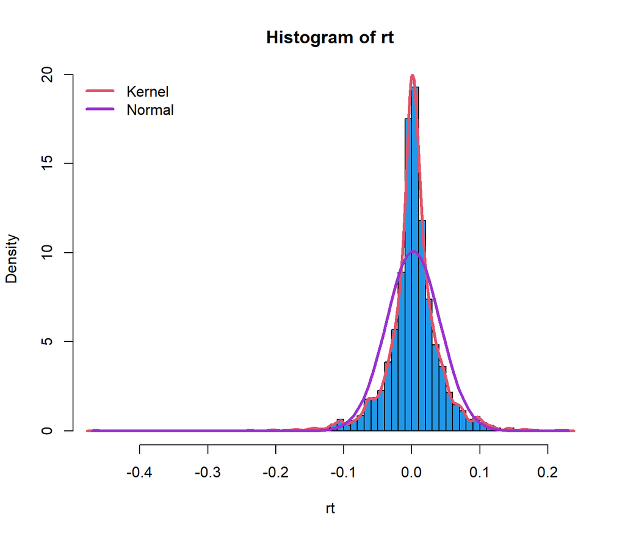

```r
hist(rt,col=4, prob=T, breaks = 50) # histogramme or rt
lines(density(rt), col=2,lwd=3) # density estimation (kernel)
curve(dnorm(x, mean(rt),sd(rt)), lwd=3, col="darkorchid3", add=T) # normal density
legend("topleft",bty="n",lwd=3, col=c(2,"darkorchid3"),
       legend=c("Kernel","Normal"))
```

```r
specSt=ugarchspec(list(garchOrder=c(1,0)), list(armaOrder=c(0,0)),distribution.model = "std")
fitst=ugarchfit(specSt,rt)
show(fitst)
```

```
*---------------------------------*
*          GARCH Model Fit        *
*---------------------------------*

Conditional Variance Dynamics
-----------------------------------
GARCH Model : sGARCH(1,0)
Mean Model  : ARFIMA(0,0,0)
Distribution    : std

Optimal Parameters
------------------------------------
        Estimate  Std. Error  t value Pr(>|t|)
mu      0.002287    0.000474   4.8272 0.000001
omega   0.002465    0.000820   3.0058 0.002649
alpha1  0.999000    0.380806   2.6234 0.008706
shape   2.291507    0.123369  18.5745 0.000000

Robust Standard Errors:
        Estimate  Std. Error  t value Pr(>|t|)
mu      0.002287    0.000486   4.7104 0.000002
omega   0.002465    0.000794   3.1057 0.001898
alpha1  0.999000    0.459204   2.1755 0.029592
shape   2.291507    0.138161  16.5858 0.000000

LogLikelihood : 5134.626

Information Criteria
------------------------------------

Akaike       -3.9680
Bayes        -3.9589
Shibata      -3.9680
Hannan-Quinn -3.9647

Weighted Ljung-Box Test on Standardized Residuals
------------------------------------
                        statistic p-value
Lag[1]                      1.139  0.2858
Lag[2*(p+q)+(p+q)-1][2]     1.412  0.3819
```

[output cut: 36 more lines]

```
Negative Sign Bias  1.5122 0.1306
Positive Sign Bias  1.6918 0.0908   *
Joint Effect        5.6371 0.1307


Adjusted Pearson Goodness-of-Fit Test:
------------------------------------
  group statistic p-value(g-1)
1    20     65.91    4.340e-07
2    30     82.56    4.856e-07
3    40     95.67    1.153e-06
4    50    103.17    9.845e-06


Elapsed time : 0.6263239
```

**Diagnostique du modèle estimé**

- Pour un modèle ARCH bien approprié, les erreurs standards $\widetilde{\varepsilon}_t=\frac{\varepsilon_t}{\sigma_t}$ doivent être $iid$. La statistique de Ljung-Box peut être appliqué sur les erreurs standards ($\widetilde{\varepsilon}_t$) pour examiner l’équation de la moyenne conditionnelle et sur leurs carrés ($\widetilde{\varepsilon}_t^2$) pour examiner l’équation de la variance conditionnelle.
- Lest tests de stochasticité (randomness tests) peuvent être aussi appliqué tels que le test BDS, run test, etc…
- Le package `rugarch` utilise plutôt les statistiques de Ljung-Box pondérée et LM-ARCH pondérée proposé par (Fisher and Gallagher 2012)
- Le package `fGarch` utilise les statistiques de Ljung-Box et LM-ARCH standards sur les erreurs standards et leurs carrés.

```r
library(fGarch)
fitst2=garchFit(~garch(1,0),rt, cond.dist = "std", trace = F )
fitst2@fit$matcoef   # fGarch
```

```
          Estimate   Std. Error   t value     Pr(>|t|)
mu     0.002290206 0.0004739852  4.831808 1.352984e-06
omega  0.002509288 0.0008199825  3.060172 2.212096e-03
alpha1 0.999999990 0.3677348660  2.719350 6.541026e-03
shape  2.286381480 0.1179821323 19.379049 0.000000e+00
```

```r
fitst@fit$matcoef    # rugarch
```

```
          Estimate   Std. Error   t value     Pr(>|t|)
mu     0.002287490 0.0004738717  4.827234 1.384422e-06
omega  0.002465219 0.0008201576  3.005787 2.648943e-03
alpha1 0.998999883 0.3808058193  2.623384 8.706109e-03
shape  2.291507174 0.1233687554 18.574453 0.000000e+00
```

```r
summary(fitst2)
```

```
Title:
 GARCH Modelling

Call:
 garchFit(formula = ~garch(1, 0), data = rt, cond.dist = "std",
    trace = F)

Mean and Variance Equation:
 data ~ garch(1, 0)
<environment: 0x000000003314f660>
 [data = rt]

Conditional Distribution:
 std

Coefficient(s):
       mu      omega     alpha1      shape
0.0022902  0.0025093  1.0000000  2.2863815

Std. Errors:
 based on Hessian

Error Analysis:
        Estimate  Std. Error  t value Pr(>|t|)
mu      0.002290    0.000474    4.832 1.35e-06 ***
omega   0.002509    0.000820    3.060  0.00221 **
alpha1  1.000000    0.367735    2.719  0.00654 **
shape   2.286382    0.117982   19.379  < 2e-16 ***
---
Signif. codes:  0 '***' 0.001 '**' 0.01 '*' 0.05 '.' 0.1 ' ' 1

Log Likelihood:
 5135.542    normalized:  1.985902

Description:
 Mon Nov 15 20:33:32 2021 by user: User


Standardised Residuals Tests:
                                Statistic p-Value
 Jarque-Bera Test   R    Chi^2  36280.16  0
 Shapiro-Wilk Test  R    W      0.8861145 0
 Ljung-Box Test     R    Q(10)  21.09798  0.02042062
 Ljung-Box Test     R    Q(15)  22.20446  0.1025538
 Ljung-Box Test     R    Q(20)  29.7996   0.07316659
 Ljung-Box Test     R^2  Q(10)  36.2839   7.522355e-05
 Ljung-Box Test     R^2  Q(15)  38.19344  0.0008447584
 Ljung-Box Test     R^2  Q(20)  39.7931   0.005304967
 LM Arch Test       R    TR^2   36.09029  0.0003133419

Information Criterion Statistics:
      AIC       BIC       SIC      HQIC
-3.968710 -3.959649 -3.968715 -3.965426
```

**Prévision**

- Les prévisions du model ARCH est obtenues récursivement comme celles du modèle AR.
- La prévision à une étape est $\sigma^2_h(1)=a_0+a_1 \varepsilon^2_h+\ldots+a_p \varepsilon^2_{h+1-p}$.
- La prévision à deux étapes est $\sigma^2_h(2)=a_0+a_1 \sigma^2_h(1)+a_2\varepsilon^2_h+\ldots+a_p \varepsilon^2_{h+2-p}$.
- La prévision à $k$ étapes est $\sigma^2_h(k)=a_0+\displaystyle \sum_{j=1}^pa_j\sigma^2_h(k-j)$ où $\sigma^2_h(k-j)=\varepsilon^2_{h+k-1}$ si $k-j \leq 0$.

```r
predict(fitst2,3)           # fGarch
```

```
  meanForecast  meanError standardDeviation
1  0.002290206 0.05567025        0.05567025
2  0.002290206 0.07488968        0.07488968
3  0.002290206 0.09009857        0.09009857
```

```r
ugarchforecast(fitst, n.ahead=3)    # rugarch
```

```
*------------------------------------*
*       GARCH Model Forecast         *
*------------------------------------*
Model: sGARCH
Horizon: 3
Roll Steps: 0
Out of Sample: 0

0-roll forecast [T0=2021-10-20]:
      Series   Sigma
T+1 0.002287 0.05527
T+2 0.002287 0.07428
T+3 0.002287 0.08931
```

- Calcul des prévisions à la main:
- On a $\widehat{\varepsilon}_T=5.9002 \times 10^{-4}$, déterminons $\widehat{\sigma}^2_T(k)$, $k=1,2,3$.
- $\widehat{\sigma}^2_T(1)=a_0+a_1 \varepsilon^2_h=2.467 \times 10^{-3}+1\times 5.9002 \times 10^{-4}=0.00305702$.
- $\widehat{\sigma}^2_T(2)=a_0+a_1 \widehat{\sigma}^2_T(1)=2.467 \times 10^{-3}+1\times 3.057 \times 10^{-3}=0.005524$.
- $\widehat{\sigma}^2_T(3)=a_0+a_1 \widehat{\sigma}^2_T(2)=2.467 \times 10^{-3}+1\times 5.524 \times 10^{-3}=0.007991$.

# Le modèle GARCH

- Le modèle GARCH (*Generalized ARCH*) est proposé par (Bollerslev 1986).
- $X_t\sim GARCH(p,q)$ si $X_t=\varepsilon_t=\sigma_tZ_t$ et $\sigma^2_t=a_0+\displaystyle \sum_{i=1}^pa_i\varepsilon^2_{t-i}+\displaystyle \sum_{j=1}^q\beta_j\sigma^2_{t-j}$ où $Z_t \stackrel{iid}{\sim}N(0,1)$, $a0 >0$, $a_i \geq 0$, $\beta_j \geq 0$ et $\displaystyle \sum_{i=1}^{\max(p,q)}(a_i+\beta_j) < 1$.
- La dernière contrainte implique que la variance inconditionnelle de $X_t$ est finie et que sa variance conditionnelle varie en fonction du temps.
- La prévision du modèle GARCH se fait similairement à un modèle ARMA. Soit $X_t=\sigma_t Z_t$ et $\sigma^2_t=a_0+a_1 \varepsilon^2_{t-1}+\beta_1\sigma^2_{t-1}$. On a alors:
- $\sigma_h(1)=a_0+a_1\varepsilon^2_h+\beta_1\sigma^2_h$,
- $\sigma_h(2)=a_0+(a_1+\beta_1)\sigma^2_h(1)+a_1\sigma^2_h(1)(Z^2_{h+1}-1)$ et puisque $\mathbb{E}(Z^2_{h+1}-1|\mathcal{I}_h)=0$, alors $\sigma_h(2)=a_0+(a_1+\beta_1)\sigma^2_h(1)$
- Et de manière générale, $\sigma_h(k)=a_0+(a_1+\beta_1)\sigma^2_h(k)$

**Remarques:**

- En générale, les modèles GARCH s’appliquent aux erreurs suite à un modèle linéaire (régression linéaire, ARMA).
- Comme dans le modèle ARCH, les erreurs $Z_t$ dans le modèle GARCH peuvent être de loi Student ou GED.
- La détermination de l’ordre $q$ du modèle GARCH se base sur la fonction d’auto-corrélation de $X_t^2$.
- Estimons les rendements du BTC à l’aide d’un modèle GARCH(1,1).

```r
garch11=garchFit(~garch(1,1),rt, trace = F)   #fGarch
garch11@fit$matcoef
```

```
           Estimate   Std. Error   t value     Pr(>|t|)
mu     2.182371e-03 6.334182e-04  3.445387 5.702419e-04
omega  6.937465e-05 1.063513e-05  6.523160 6.884138e-11
alpha1 1.339155e-01 1.523577e-02  8.789549 0.000000e+00
beta1  8.365670e-01 1.548134e-02 54.037112 0.000000e+00
```

```r
spec11=ugarchspec(variance.model = list(garchOrder=c(1,1)),
                  mean.model = list(armaOrder=c(0,0)))
Garch11=ugarchfit(spec11,rt)
Garch11@fit$matcoef
```

```
           Estimate   Std. Error   t value     Pr(>|t|)
mu     2.182108e-03 6.334382e-04  3.444864 5.713467e-04
omega  6.933686e-05 1.066024e-05  6.504249 7.808243e-11
alpha1 1.337894e-01 1.523686e-02  8.780639 0.000000e+00
beta1  8.366535e-01 1.551168e-02 53.937005 0.000000e+00
```

```r
summary(garch11)
```

```
Title:
 GARCH Modelling

Call:
 garchFit(formula = ~garch(1, 1), data = rt, trace = F)

Mean and Variance Equation:
 data ~ garch(1, 1)
<environment: 0x000000003204a810>
 [data = rt]

Conditional Distribution:
 norm

Coefficient(s):
        mu       omega      alpha1       beta1
2.1824e-03  6.9375e-05  1.3392e-01  8.3657e-01

Std. Errors:
 based on Hessian

Error Analysis:
        Estimate  Std. Error  t value Pr(>|t|)
mu     2.182e-03   6.334e-04    3.445  0.00057 ***
omega  6.937e-05   1.064e-05    6.523 6.88e-11 ***
alpha1 1.339e-01   1.524e-02    8.790  < 2e-16 ***
beta1  8.366e-01   1.548e-02   54.037  < 2e-16 ***
---
Signif. codes:  0 '***' 0.001 '**' 0.01 '*' 0.05 '.' 0.1 ' ' 1

Log Likelihood:
 4910.658    normalized:  1.89894

Description:
 Mon Nov 15 20:33:32 2021 by user: User


Standardised Residuals Tests:
                                Statistic p-Value
 Jarque-Bera Test   R    Chi^2  21488.29  0
 Shapiro-Wilk Test  R    W      0.8992033 0
 Ljung-Box Test     R    Q(10)  29.43062  0.001060873
 Ljung-Box Test     R    Q(15)  31.22058  0.008206586
 Ljung-Box Test     R    Q(20)  37.26145  0.01088514
 Ljung-Box Test     R^2  Q(10)  3.238863  0.9752308
 Ljung-Box Test     R^2  Q(15)  4.254493  0.9967773
 Ljung-Box Test     R^2  Q(20)  5.188875  0.9996305
 LM Arch Test       R    TR^2   3.432893  0.9916394

Information Criterion Statistics:
      AIC       BIC       SIC      HQIC
-3.794786 -3.785725 -3.794791 -3.791502
```

```r
show(Garch11)
```

```
*---------------------------------*
*          GARCH Model Fit        *
*---------------------------------*

Conditional Variance Dynamics
-----------------------------------
GARCH Model : sGARCH(1,1)
Mean Model  : ARFIMA(0,0,0)
Distribution    : norm

Optimal Parameters
------------------------------------
        Estimate  Std. Error  t value Pr(>|t|)
mu      0.002182    0.000633   3.4449 0.000571
omega   0.000069    0.000011   6.5042 0.000000
alpha1  0.133789    0.015237   8.7806 0.000000
beta1   0.836654    0.015512  53.9370 0.000000

Robust Standard Errors:
        Estimate  Std. Error  t value Pr(>|t|)
mu      0.002182    0.000729   2.9930 0.002762
omega   0.000069    0.000026   2.6688 0.007612
alpha1  0.133789    0.036614   3.6540 0.000258
beta1   0.836654    0.027806  30.0894 0.000000

LogLikelihood : 4910.635

Information Criteria
------------------------------------

Akaike       -3.7948
Bayes        -3.7857
Shibata      -3.7948
Hannan-Quinn -3.7915

Weighted Ljung-Box Test on Standardized Residuals
------------------------------------
                        statistic p-value
Lag[1]                      4.384 0.03628
Lag[2*(p+q)+(p+q)-1][2]     4.936 0.04230
```

[output cut: 36 more lines]

```
Negative Sign Bias  0.5948 0.5520
Positive Sign Bias  0.4544 0.6496
Joint Effect        1.7634 0.6229


Adjusted Pearson Goodness-of-Fit Test:
------------------------------------
  group statistic p-value(g-1)
1    20     392.4    1.649e-71
2    30     429.5    7.774e-73
3    40     431.9    9.983e-68
4    50     462.6    1.103e-68


Elapsed time : 0.157547
```

```r
ugarchforecast(Garch11,n.ahead = 5)
```

```
*------------------------------------*
*       GARCH Model Forecast         *
*------------------------------------*
Model: sGARCH
Horizon: 5
Roll Steps: 0
Out of Sample: 0

0-roll forecast [T0=2021-10-20]:
      Series   Sigma
T+1 0.002182 0.03436
T+2 0.002182 0.03486
T+3 0.002182 0.03534
T+4 0.002182 0.03579
T+5 0.002182 0.03623
```

**Références**

Bollerslev, Tim. 1986. “Generalized Autoregressive Conditional Heteroskedasticity.” *Journal of Econometrics* 31 (3): 307–27. https://doi.org/https://doi.org/10.1016/0304-4076(86)90063-1.

Engle, Robert F. 1982. “Autoregressive Conditional Heteroscedasticity with Estimates of the Variance of United Kingdom Inflation.” *Econometrica* 50 (4): 987–1007.

Fisher, Thomas J., and Colin M. Gallagher. 2012. “New Weighted Portmanteau Statistics for Time Series Goodness of Fit Testing.” *Journal of the American Statistical Association* 107 (498): 777–87. https://doi.org/10.1080/01621459.2012.688465.